%%markdown

# Rondonia: NDVI in 2002 Minus NDVI in 1992

Reproduce the calculation in textbook Figure 15.1 using two documented Landsat 5 TM crops near Ariquemes, Brazil. The original caption does not identify its scenes or crop, so this is a methodological reproduction, not the exact textbook image.

[Open in Colab](https://colab.research.google.com/github/jfemiani/cse620b-public/blob/main/Lessons/09-Change-Detection-and-Accuracy-Assessment/demo-rondonia-ndvi.ipynb)

%%markdown

## Check the conditions before subtracting

- Landsat 5 TM, Collection 2 Level-2 surface reflectance, 30 m pixels.
- 1992-03-10: LT05_L2SP_232067_19920310_02_T2.
- 2002-02-02: LT05_L2SP_232067_20020202_02_T1.
- Both crops have the same grid, but Tier 2 feature registration is unverified.
- March versus February can introduce phenology and moisture differences.
- Cloud masking leaves only about 24% common coverage. QA_RADSAT is not bundled, so this is not a complete analysis-ready or validated change map.

Data: USGS Landsat via Microsoft Planetary Computer. [Provenance and source URLs](https://github.com/jfemiani/cse620b-public/releases/download/rondonia-ndvi-v1/provenance.json). In a fresh Colab runtime, run `%pip install rasterio` before the import cell.

%%markdown

## Scale first, then compute NDVI

$$\rho = 0.0000275\,\mathrm{DN}-0.2,\qquad \mathrm{NDVI}=\frac{\rho_{NIR}-\rho_{red}}{\rho_{NIR}+\rho_{red}}$$

TM band 3 is red and band 4 is NIR. These crops store red, NIR, and QA_PIXEL as bands 1, 2, and 3. The additive offset does not cancel from the NDVI denominator. Exclude fill, dilated cloud, cloud, shadow, and snow flags; then retain nonnegative reflectances with a positive denominator.

```python
ndvi = {}
transforms = []
for year in (1992, 2002):
    with rasterio.open(data_dir / f"rondonia-{year}.tif") as source:
        red_dn, nir_dn, quality = source.read()
        transforms.append(source.transform)
    red = red_dn.astype(np.float32) * 0.0000275 - 0.2
    nir = nir_dn.astype(np.float32) * 0.0000275 - 0.2
    valid = ((quality & 63) == 0) & (red_dn != 0) & (nir_dn != 0)
    valid &= (red >= 0) & (nir >= 0) & (nir + red > 0)
    values = np.full(red.shape, np.nan, dtype=np.float32)
    np.divide(nir - red, nir + red, out=values, where=valid)
    ndvi[year] = values
assert transforms[0] == transforms[1], "Pixel grids must agree before subtraction"
common = np.isfinite(ndvi[1992]) & np.isfinite(ndvi[2002])
difference = np.where(common, ndvi[2002] - ndvi[1992], np.nan)
print(f"Comparable pixels: {common.sum():,} / {common.size:,} ({common.mean():.1%})")
print(f"NDVI difference range: {np.nanmin(difference):.3f} to {np.nanmax(difference):.3f}")
```

```
Comparable pixels: 15,925 / 65,536 (24.3%)
NDVI difference range: -0.600 to 0.745
```

%%markdown

## Same pixels, same display scale

Grey pixels are excluded on either date. The common mask is used in every panel so cloud boundaries do not become apparent changes in the flicker test. NDVI maps share [-1, 1]. Difference brightness also uses fixed limits [-1, 1]: zero is middle grey, positive is brighter, negative is darker. This clips display values outside that interval; numerical NDVI differences can reach [-2, 2]. The displayed limits never change between dates.

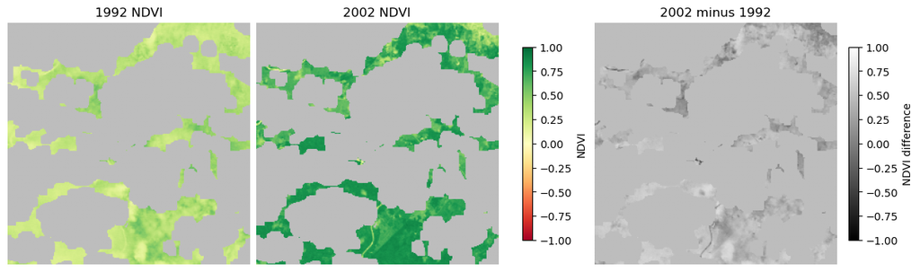

```python
ndvi_cmap = plt.colormaps["RdYlGn"].with_extremes(bad="#bdbdbd")
change_cmap = plt.colormaps["gray"].with_extremes(bad="#bdbdbd")
fig, axes = plt.subplots(1, 3, figsize=(12, 4), layout="constrained")
for axis, year in zip(axes[:2], (1992, 2002)):
    panel = axis.imshow(np.where(common, ndvi[year], np.nan), cmap=ndvi_cmap, vmin=-1, vmax=1)
    axis.set_title(f"{year} NDVI")
fig.colorbar(panel, ax=axes[:2], shrink=0.65, label="NDVI")
panel = axes[2].imshow(difference, cmap=change_cmap, vmin=-1, vmax=1)
axes[2].set_title("2002 minus 1992")
fig.colorbar(panel, ax=axes[2], shrink=0.65, label="NDVI difference")
for axis in axes:
    axis.axis("off")
fig.savefig(output_dir / "rondonia-ndvi-comparison.png", dpi=150)
plt.show()
```

%%markdown

## Flicker between the two NDVI maps

Both frames have identical dimensions, masks, and stretch. Alternate the exported PNGs in adjacent presentation slides, or view the animated GIF. Inspect persistent patterns, then ask what else besides land-cover change could explain them. Do not estimate cleared forest area from this sample.

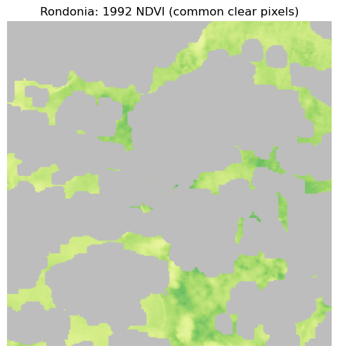

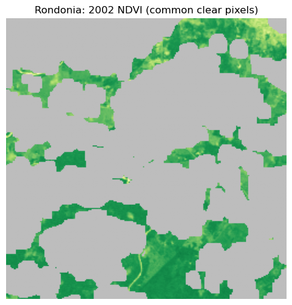

```python
frames = []
for year in (1992, 2002):
    fig, axis = plt.subplots(figsize=(6, 6))
    axis.imshow(np.where(common, ndvi[year], np.nan), cmap=ndvi_cmap, vmin=-1, vmax=1)
    axis.set_title(f"Rondonia: {year} NDVI (common clear pixels)")
    axis.axis("off")
    path = output_dir / f"rondonia-{year}-ndvi.png"
    fig.savefig(path, dpi=120)
    plt.show()
    with Image.open(path) as frame:
        frames.append(frame.convert("RGB"))
frames[0].save(output_dir / "rondonia-ndvi-flicker.gif", save_all=True,
               append_images=frames[1:], duration=900, loop=0)
```

%%markdown

## What this reproduces

Figure 15.1's operation and sign convention: NDVI in 2002 minus NDVI in 1992, in Rondonia, using Landsat 5 TM. It does not reproduce the undocumented original footprint or acquisition dates. Better-matched cloud-free scenes, saturation checks, verified registration, and independent reference data are needed before attributing these spectral differences to deforestation.